# Bootstrap

## Introdução

- Bootstrap foi introduzido em 1979 por Efron;
- Estratégias de Bootstrap compõem uma classe de métodos não-paramétricos de Monte Carlo que estimam a distribuição de uma população por meio de reamostragem;
- Métodos de reamostragem tratam amostras como uma população finita, a partir da qual reamostras são tomadas para estimar características e realizar inferências a respeito desta população;
- Métodos de Bootstrap são habitualmente empregados quando a distribuição da população-alvo não é especificada.

## Introdução

Suponha que \(x = (x_1, \dots, x_n)\) é uma amostra aleatória de uma distribuição \(F_X\). Se \(X^{*}\) é selecionado aleatóriamente de \(x\), então:

\[ P(X^{*}=x_i) = \frac{1}{n}.\]

Reamostragem gera uma amostra aleatória \(X^{*}_1, \dots, X^{*}_n\) por meio de amostragem com reposição. As variáveis aleatórias \(X^{*}_i\) são iid e uniformimente distribuídas no conjunto \(\{x_1, \dots, x_n\}\).

## Introdução

- Observe que a Função Empírica de Distribuição \(F_n(x)\) é um estimador de \(F_X(x)\);
- Note que a distribuição de \(X^{*}\) é \(F_n(x)\);
- Além disso, a Função Empírica de Distribuicão \(F_n^{*}(x)\) é um estimador de \(F_n(x)\);

## Geração de Amostras Bootstrap

Para gerar uma amostra boostrap aleatória por reamostragem de \(x\), gere \(n\) inteiros aleatórios uniformemente distribuídos no conjunto \(\{1, \dots, n\}\) e selecione a amostra bootstrap como \(x^{*} = (x_{i_1}, \dots, x_{i_n})\).

## Geração de Amostras Bootstrap

Suponha que \(\theta\) seja o parâmetro de interesse (que pode ser vetorial) e que \(\hat{\theta}\) seja um estimador de \(\theta\). Então, a estimativa bootstrap da distribuição de \(\hat{\theta}\) é obtida da seguinte maneira:

1. Para a \(b\)-ésima replicata bootstrap, para a qual \(b \in [1, B]\):
   - Gere a amostra \(x^{*(b)} = x^{*}_1, \dots, x^{*}_n\) por meio de reamostragem com reposição a partir de \(x_1, \dots, x_n\) (a amostra observada);
   - Determine o \(b\)-ésimo estimador (de bootstrap) \(\hat{\theta}^{(b)}\);
2. A estimativa de \(F_{\hat{\theta}}(\cdot)\) é a distribuição empírica das réplicas \(\hat{\theta}^{(1)}, \dots, \hat{\theta}^{(B)}\).

## Exemplo

Suponha que observamos os seguintes dados:

\[ x = \{2, 2, 1, 1, 5, 4, 4, 3, 1, 2\}.\]

Reamostrando de \(x\), selecionamos \(\{1, 2, 3, 4, 5\}\) com probabilidades \(\{0.3, 0.3, 0.1, 0.2, 0.1\}\). A distribuição \(F_{X^{*}}(x)\) de uma amostra tomada aleatoriamente é exatamente a função \(F_n(x)\):

\[ \begin{align} F_{X^{*}}(x) = F_n(x) = \begin{cases} 0.0 & x < 1; \\ 0.3 & 1 \leq x < 2;\\ 0.6 & 2 \leq x < 3;\\ 0.7 & 3 \leq x < 4;\\ 0.9 & 4 \leq x < 5;\\ 1.0 & x \geq 5. \end{cases} \end{align} \]

## Estimação por Bootstrap do Erro-Padrão

A estimativa bootstrap do erro-padrão de um estimador \(\hat{\theta}\) é o erro-padrão amostral das replicatas bootstrap \(\hat{\theta}^{(1)}, \dots, \hat{\theta}^{(B)}\):

\[ \mbox{se}\left(\hat{\theta}^{*}\right) = \sqrt{ \frac{1}{B-1} \sum_{b=1}^B \left( \hat{\theta}^{(b)} - \overline{\hat{\theta}^{*}} \right)^2}, \]

\[\overline{\hat{\theta}^{*}} = \frac{1}{B}\sum_{b=1}^B \hat{\theta}^{(b)}. \]

## Exemplo

- O conjunto de dados `cars` apresenta duas variáveis:
  1. `dist`: distância percorrida até a parada total;
  2. `speed`: velocidade no início da frenagem.
- Esta é uma amostra de 50 veículos;
- Estime a correlação entre `dist` e `speed` usando bootstrap;

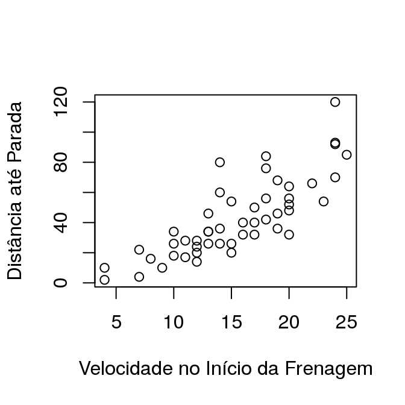

## Exemplo

Bootstrap "manual":

```r
set.seed(1)
B = 10000
boot_corr = vector('numeric', B)
for (b in 1:B){
    indices = sample(nrow(cars), rep=TRUE)
    boot_corr[b] = with(cars[indices,], cor(dist, speed))
}
(theta_star = mean(boot_corr))
```

```
## [1] 0.8062458
```

```r
(se_theta_star = sd(boot_corr))
```

```
## [1] 0.04782856
```

## Exemplo

Bootstrap via pacote `boot`:

```r
set.seed(1)
library(boot)
res = boot(cars,
           function(dd, i) with(dd[i,], cor(dist, speed)),
           R=10000)
```

## Exemplo

Bootstrap via pacote `boot`:

```
##
## ORDINARY NONPARAMETRIC BOOTSTRAP
##
##
## Call:
## boot(data = cars, statistic = function(dd, i) with(dd[i, ], cor(dist,
##     speed)), R = 10000)
##
##
## Bootstrap Statistics :
##      original        bias    std. error
## t1* 0.8068949 -0.0006317705  0.04751415
```

## Estimativa Bootstrap do Vício

A definição de vício é dada por: \[B(\hat{\theta}) = E ( \hat{\theta}) - \theta\]

Deste modo, a estimativa bootstrap do vício é: \[\hat{B(\hat{\theta})} = \overline{\hat{\theta}^{*}} - \hat{\theta},\]

expressão na qual \(\overline{\hat{\theta}^{*}} = \frac{1}{B} \sum_{b=1}^B \hat{\theta}^{(b)}\) e \(\hat{\theta}\) é a estimativa calculada utilizando a amostra original.

## Exemplo

No exemplo da correlação no conjunto de dados `cars`, a correlação no conjunto original é 0.8069. Determinamos a estimativa bootstrap como 0.8062. Desta maneira o vício é:

```r
theta_star - with(cars, cor(dist, speed))
```

```
## [1] -0.0006490941
```